# ARIMA Analysis of U.S. Domestic Airline Passenger Boardings

Nihar Shah

November 23, 2026

## Data

The data contain monthly U.S. domestic airline passenger boardings, measured in **thousands**, from January 2000 through May 2026. These are passenger boardings, not counts of departing aircraft.

```r
library(fpp2)
```

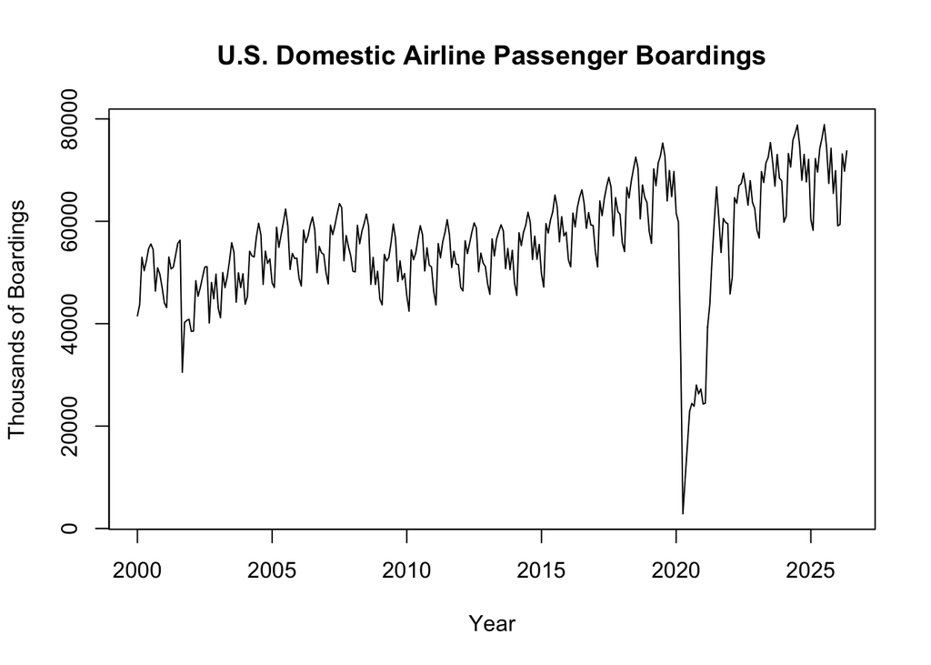

```r
library(forecast)

airline_data <- read.csv("us_domestic_airline_enplanements_monthly.csv")
passengers <- ts(airline_data$ENPLANED, start = c(2000, 1), frequency = 12)

plot(passengers, main = "U.S. Domestic Airline Passenger Boardings",
     xlab = "Year", ylab = "Thousands of Boardings")
```

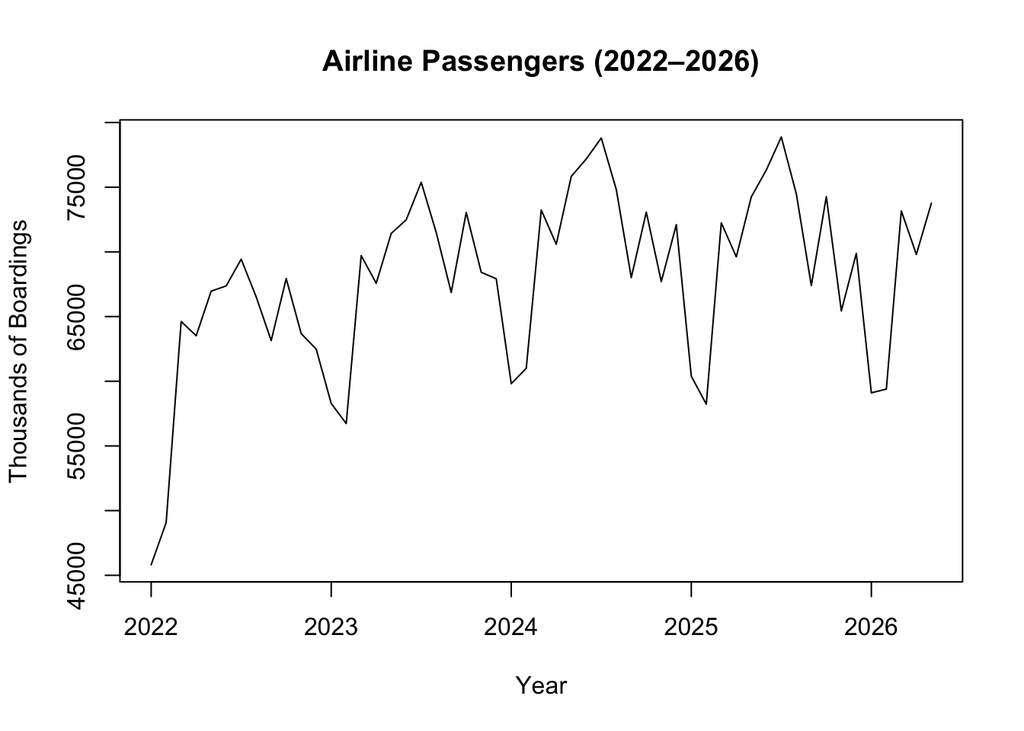

```r
passengers_no_covid <- window(passengers,
                              start = c(2022, 1))

plot(passengers_no_covid,
     main = "Airline Passengers (2022–2026)",
     ylab = "Thousands of Boardings",
     xlab = "Year")
```

## 1. ARIMA Model and Output

The time series is monthly, so its seasonal period is 12. The following checks examine whether nonseasonal and seasonal differencing may be needed. `auto.arima()` then selects a model automatically.

```r
nsdiffs(passengers_no_covid)
```

```
## [1] 1
```

```r
ndiffs(passengers_no_covid)
```

```
## [1] 1
```

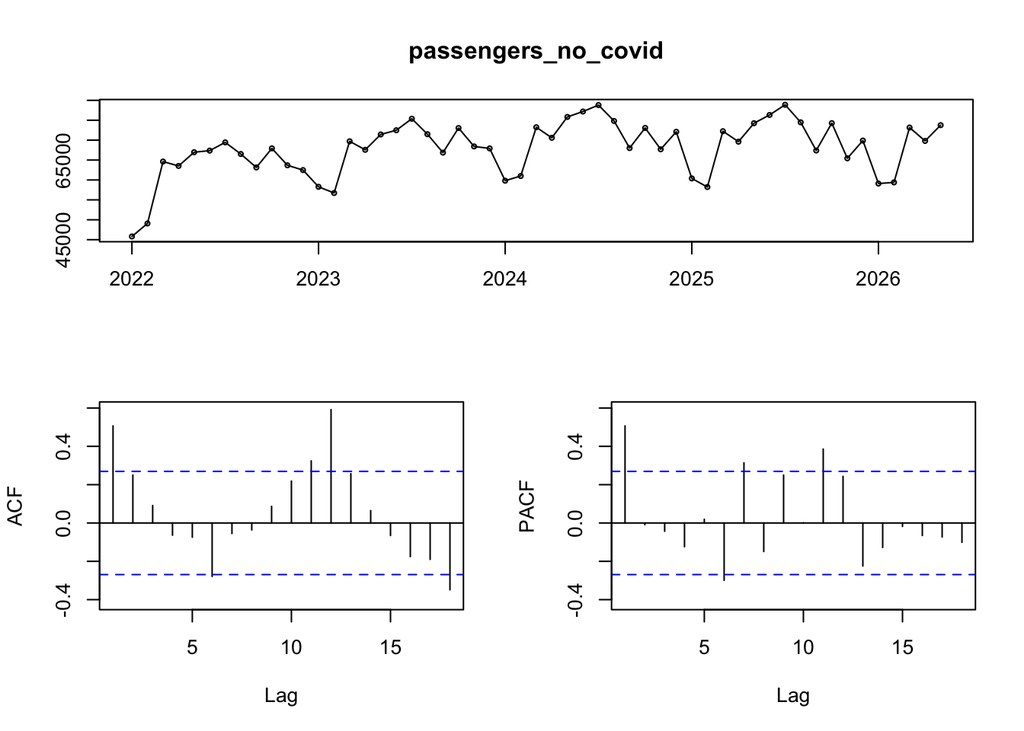

```r
tsdisplay(passengers_no_covid)
```

```r
ARIMA_model <- auto.arima(passengers_no_covid,
                          trace = TRUE,
                          stepwise = FALSE)
```

```
##
##  ARIMA(0,1,0)(0,1,0)[12]                    : 720.452
##  ARIMA(0,1,0)(0,1,1)[12]                    : 722.2874
##  ARIMA(0,1,0)(1,1,0)[12]                    : 722.1693
##  ARIMA(0,1,0)(1,1,1)[12]                    : Inf
##  ARIMA(0,1,1)(0,1,0)[12]                    : 721.1698
##  ARIMA(0,1,1)(0,1,1)[12]                    : 722.4904
##  ARIMA(0,1,1)(1,1,0)[12]                    : 722.2739
##  ARIMA(0,1,1)(1,1,1)[12]                    : Inf
##  ARIMA(0,1,2)(0,1,0)[12]                    : 721.5934
##  ARIMA(0,1,2)(0,1,1)[12]                    : 723.7635
##  ARIMA(0,1,2)(1,1,0)[12]                    : 723.6444
##  ARIMA(0,1,2)(1,1,1)[12]                    : Inf
##  ARIMA(0,1,3)(0,1,0)[12]                    : 724.0657
##  ARIMA(0,1,3)(0,1,1)[12]                    : 726.3776
##  ARIMA(0,1,3)(1,1,0)[12]                    : 726.2569
##  ARIMA(0,1,3)(1,1,1)[12]                    : Inf
##  ARIMA(0,1,4)(0,1,0)[12]                    : 724.8377
##  ARIMA(0,1,4)(0,1,1)[12]                    : 727.1175
##  ARIMA(0,1,4)(1,1,0)[12]                    : 726.9627
##  ARIMA(0,1,5)(0,1,0)[12]                    : 726.7284
##  ARIMA(1,1,0)(0,1,0)[12]                    : 721.9248
##  ARIMA(1,1,0)(0,1,1)[12]                    : 723.396
##  ARIMA(1,1,0)(1,1,0)[12]                    : 723.1815
##  ARIMA(1,1,0)(1,1,1)[12]                    : Inf
##  ARIMA(1,1,1)(0,1,0)[12]                    : 722.2353
##  ARIMA(1,1,1)(0,1,1)[12]                    : 724.0883
##  ARIMA(1,1,1)(1,1,0)[12]                    : 723.9198
##  ARIMA(1,1,1)(1,1,1)[12]                    : Inf
##  ARIMA(1,1,2)(0,1,0)[12]                    : 724.068
##  ARIMA(1,1,2)(0,1,1)[12]                    : 726.3825
##  ARIMA(1,1,2)(1,1,0)[12]                    : 726.2629
##  ARIMA(1,1,2)(1,1,1)[12]                    : Inf
##  ARIMA(1,1,3)(0,1,0)[12]                    : 725.6349
##  ARIMA(1,1,3)(0,1,1)[12]                    : 726.677
##  ARIMA(1,1,3)(1,1,0)[12]                    : 728.426
##  ARIMA(1,1,4)(0,1,0)[12]                    : Inf
##  ARIMA(2,1,0)(0,1,0)[12]                    : 722.2415
##  ARIMA(2,1,0)(0,1,1)[12]                    : 724.5316
##  ARIMA(2,1,0)(1,1,0)[12]                    : 724.4385
```

[output cut: 11 more lines]

```
##  ARIMA(3,1,0)(1,1,0)[12]                    : 725.872
##  ARIMA(3,1,0)(1,1,1)[12]                    : Inf
##  ARIMA(3,1,1)(0,1,0)[12]                    : 726.1873
##  ARIMA(3,1,1)(0,1,1)[12]                    : 728.5978
##  ARIMA(3,1,1)(1,1,0)[12]                    : 728.4493
##  ARIMA(3,1,2)(0,1,0)[12]                    : 728.5889
##  ARIMA(4,1,0)(0,1,0)[12]                    : 726.3358
##  ARIMA(4,1,0)(0,1,1)[12]                    : 728.7169
##  ARIMA(4,1,0)(1,1,0)[12]                    : 728.5545
##  ARIMA(4,1,1)(0,1,0)[12]                    : 728.9665
##  ARIMA(5,1,0)(0,1,0)[12]                    : 728.0456
##
##
##
##  Best model: ARIMA(0,1,0)(0,1,0)[12]
```

```r
ARIMA_model
```

```
## Series: passengers_no_covid
## ARIMA(0,1,0)(0,1,0)[12]
##
## sigma^2 = 3689528:  log likelihood = -359.17
## AIC=720.35   AICc=720.45   BIC=722.04
```

### ARIMA Model Output and Interpretation

After excluding the COVID-19 period, auto.arima() selected ARIMA(0,1,0)(0,1,0)[12]. The model requires one regular difference and one seasonal difference to account for changes and yearly patterns in airline passenger traffic.

## 2. Residual Analysis

The residuals are the differences between actual and fitted values. A useful ARIMA model should leave residuals with no clear pattern or meaningful remaining autocorrelation.

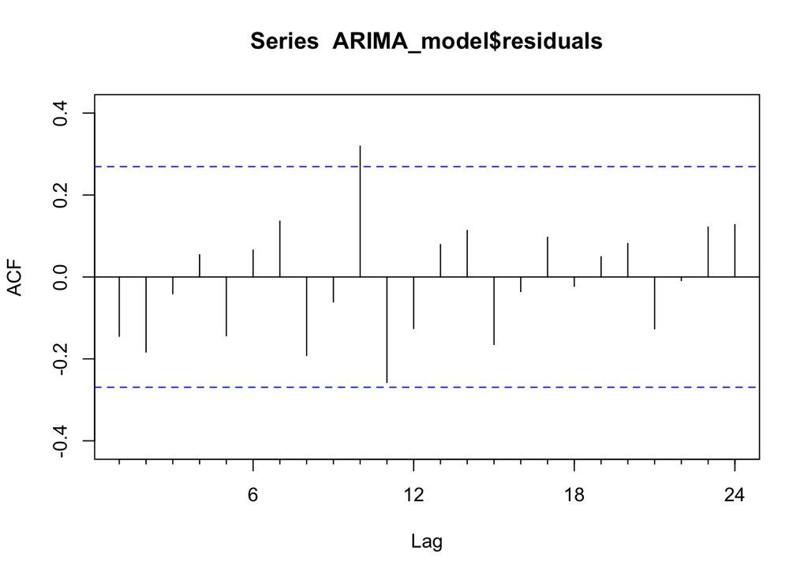

```r
Acf(ARIMA_model$residuals)
```

```r
Box.test(residuals(ARIMA_model),
         lag = 20,
         type = "Ljung")
```

```
##
##  Box-Ljung test
##
## data:  residuals(ARIMA_model)
## X-squared = 26.561, df = 20, p-value = 0.1481
```

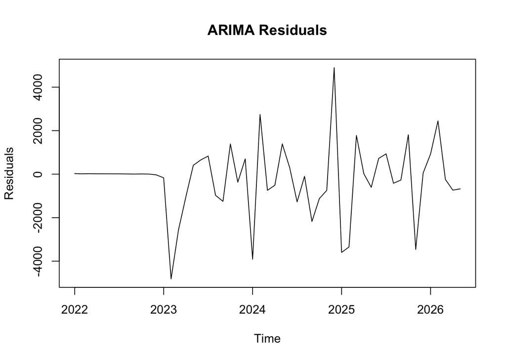

```r
plot.ts(residuals(ARIMA_model),
        main = "ARIMA Residuals",
        ylab = "Residuals")
```

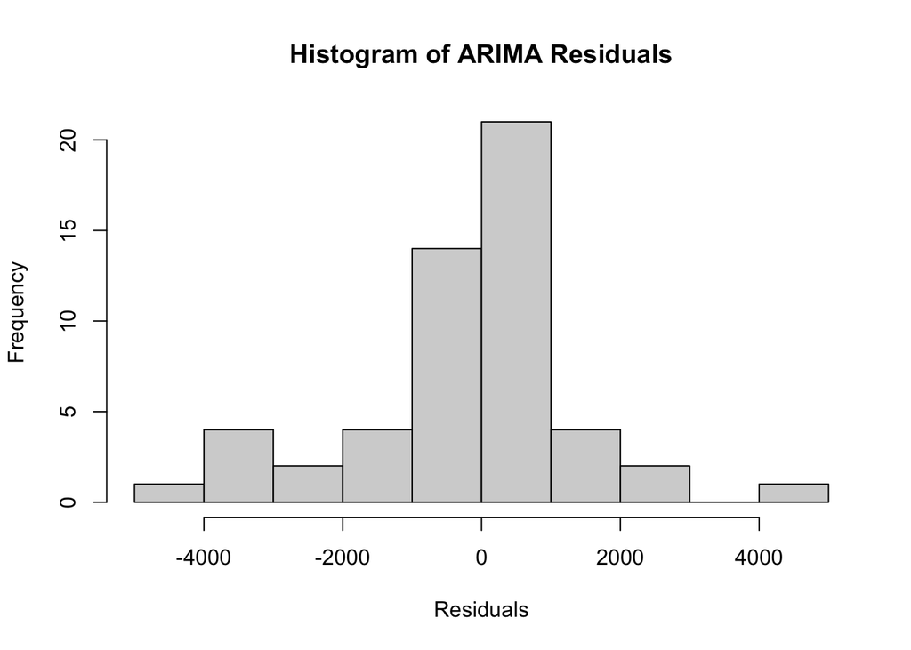

```r
hist(ARIMA_model$residuals,
     main = "Histogram of ARIMA Residuals",
     xlab = "Residuals")
```

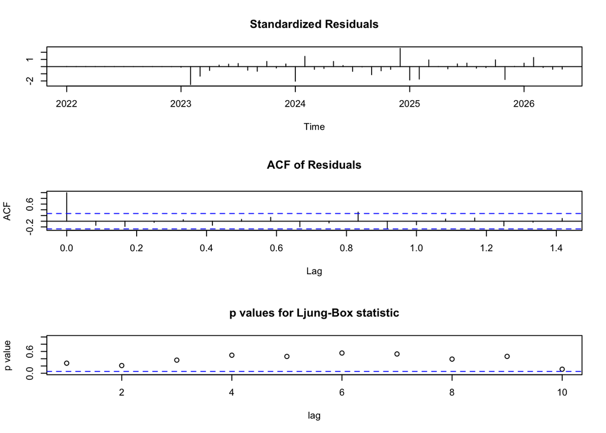

```r
tsdiag(ARIMA_model)
```

## 3. Five-Period Forecast

The final historical observation in the supplied data is May 2026. Therefore, the next **five monthly periods** are June, July, August, September, and October 2026. Following the professor’s ARIMA example, the forecast is displayed with a 99.5% prediction interval.

```r
ARIMA_forecast <- forecast(ARIMA_model,
                          h = 5,
                          level = c(99.5))

ARIMA_forecast
```

```
##          Point Forecast  Lo 99.5  Hi 99.5
## Jun 2026          75836 70444.21 81227.79
## Jul 2026          78389 70763.86 86014.14
## Aug 2026          73986 64647.14 83324.86
## Sep 2026          66906 56122.42 77689.58
## Oct 2026          73779 61722.59 85835.41
```

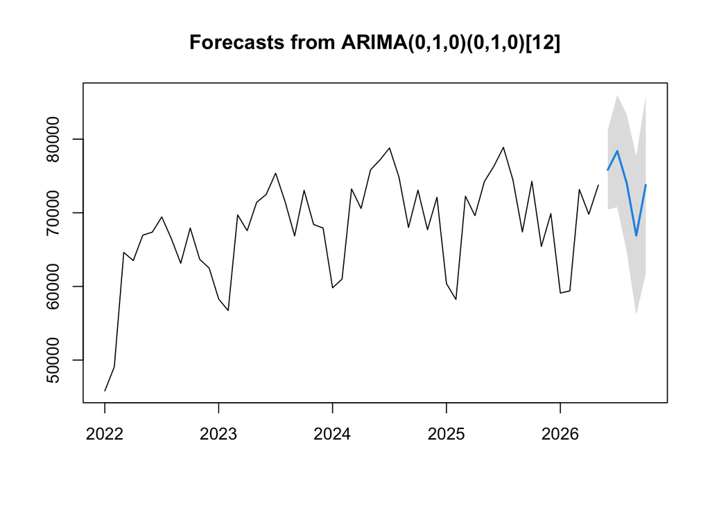

```r
plot(ARIMA_forecast)
```

### ARIMA Forecast for the Next Five Months

The ARIMA model forecasts airline passenger boardings from June to October 2026. Passenger traffic is expected to increase from 75.8 million in June to 78.4 million in July, before declining to 66.9 million in September and recovering to 73.8 million in October.

July is expected to have the highest passenger traffic, while September has the lowest. This follows the usual seasonal pattern of increased travel during the summer months.

The 99.5% prediction intervals become wider over time, indicating greater uncertainty in longer-term forecasts. Overall, the model predicts seasonal fluctuations in airline passenger traffic.

## 4. ARIMA Model Accuracy

The `accuracy()` function reports error measures for the fitted ARIMA model.

```r
accuracy(ARIMA_model)
```

```
##                     ME     RMSE     MAE        MPE     MAPE      MASE
## Training set -245.5483 1668.697 1081.27 -0.4281186 1.638821 0.3647589
##                    ACF1
## Training set -0.1449577
```

###ARIMA Model Accuracy

The ARIMA model produced an RMSE of 1668.70 and an MAE of 1081.27, indicating relatively small errors in predicting airline passenger boardings.

The MAPE of 1.64% shows that the model’s predictions differ from actual passenger numbers by only about 1.64% on average.

Overall, the model fits the historical data well, with relatively low forecasting errors. Combined with the residual analysis, these results suggest that the ARIMA model captures the patterns in airline passenger traffic reasonably well. However, these accuracy measures are based on the training data, so actual future forecasting performance may differ.